# week_08_jointdensity_jointplots_pairsplots

## CMPINF 2130 Summer 2021 - Week 08

### Joint density plots, joint plots, and pairs plots in Seaborn

## Import modules

```python
import numpy as np
import pandas as pd
import matplotlib.pyplot as plt

import seaborn as sns
```

## Iris data

```python
import statsmodels.api as sm
```

```python
iris = sm.datasets.get_rdataset('iris').data
```

```python
iris.info()
```

```
<class 'pandas.core.frame.DataFrame'>
RangeIndex: 150 entries, 0 to 149
Data columns (total 5 columns):
 #   Column        Non-Null Count  Dtype
---  ------        --------------  -----
 0   Sepal.Length  150 non-null    float64
 1   Sepal.Width   150 non-null    float64
 2   Petal.Length  150 non-null    float64
 3   Petal.Width   150 non-null    float64
 4   Species       150 non-null    object
dtypes: float64(4), object(1)
memory usage: 6.0+ KB
```

## Joint distribution

We can create a scatter plot between two continuous variables in Seaborn.

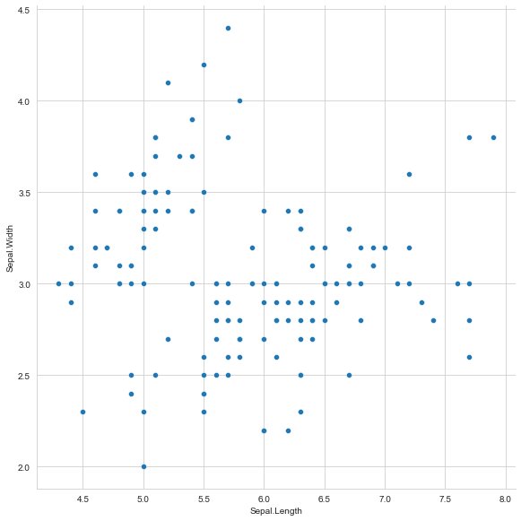

```python
sns.set_style('whitegrid')

sns.relplot(data = iris, x='Sepal.Length', y='Sepal.Width', kind='scatter', height=8)

plt.show()
```

We also know how to color or condition on a categorical variable via the `hue` semantic argument.

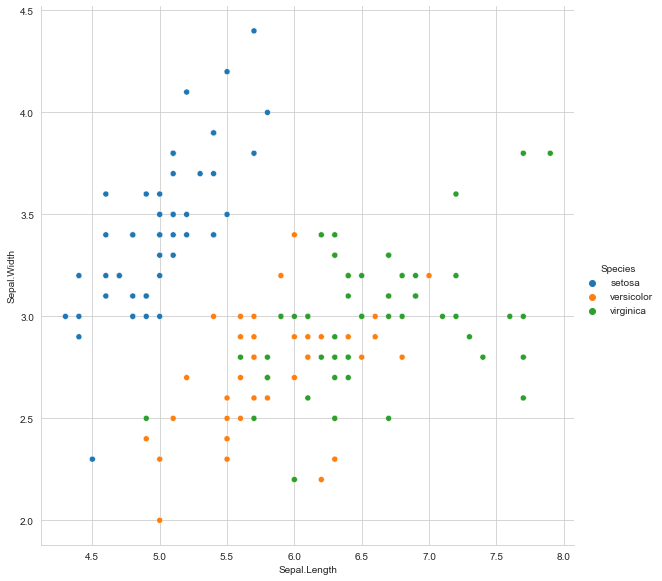

```python
sns.relplot(data = iris, x='Sepal.Length', y='Sepal.Width', hue='Species',
            kind='scatter', height=8)

plt.show()
```

### 2D histogram

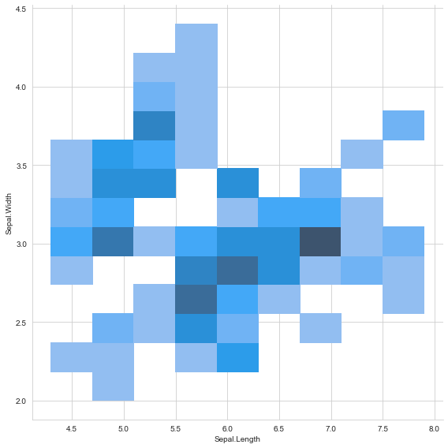

```python
sns.displot(data = iris, x='Sepal.Length', y='Sepal.Width', kind='hist', height=8)

plt.show()
```

We can set the `cbar` argument to `True` to include the legend.

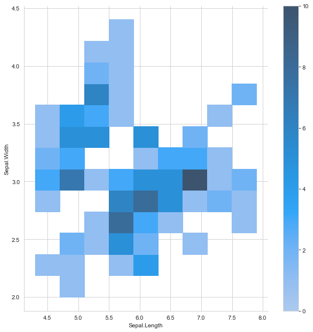

```python
sns.displot(data = iris, x='Sepal.Length', y='Sepal.Width', kind='hist', height=8,
            cbar=True)

plt.show()
```

Alternatively we can smooth out the counts and get an estimate for the density via a 2D kernel density estimate.

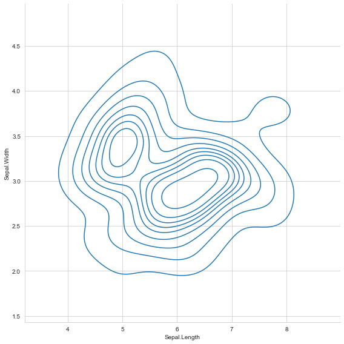

```python
sns.displot(data = iris, x='Sepal.Length', y='Sepal.Width', kind='kde', height=8)

plt.show()
```

Include the rug tick marks for additional context.

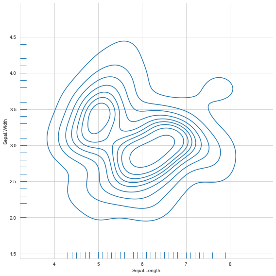

```python
sns.displot(data = iris, x='Sepal.Length', y='Sepal.Width', kind='kde', height=8,
            rug=True)

plt.show()
```

We can color the 2D kernel density estimate by a categorical therefore having the *conditional* kde.

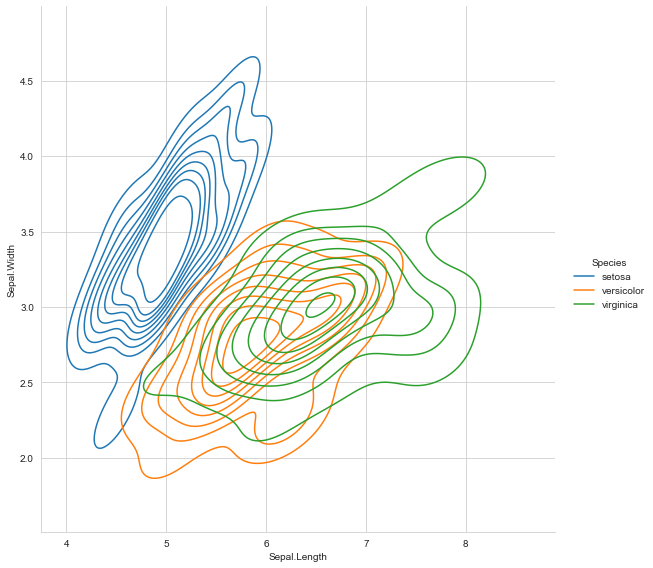

```python
sns.displot(data = iris, x='Sepal.Length', y='Sepal.Width', hue='Species',
            kind='kde', height=8)

plt.show()
```

## Joint plots

Seaborn's terminology for combining a joint distribution with marginal distributions outside the main axis. Use 2D kde plot for the joint distribution and a 1D kde for the marginal distributions.

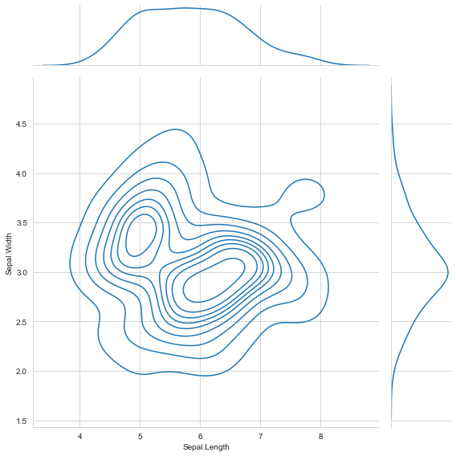

```python
sns.jointplot(data = iris, x='Sepal.Length', y='Sepal.Width', kind='kde', height=8)

plt.show()
```

Instead we could use a scatter plot for the joint behavior and univariate histograms for the marginals. This is the default `sns.jointplot()` functionality.

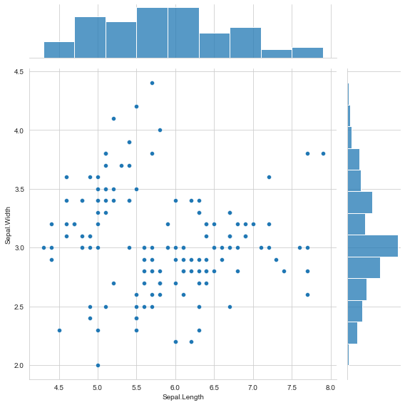

```python
sns.jointplot(data = iris, x='Sepal.Length', y='Sepal.Width', height=8)

plt.show()
```

Alternatively we can use 2D histogram for the joint distribution.

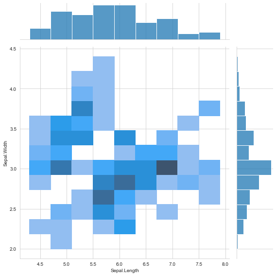

```python
sns.jointplot(data = iris, x='Sepal.Length', y='Sepal.Width', kind='hist', height=8)

plt.show()
```

Is `sns.jointplot()` includes hexbins to represent the joint distribution!

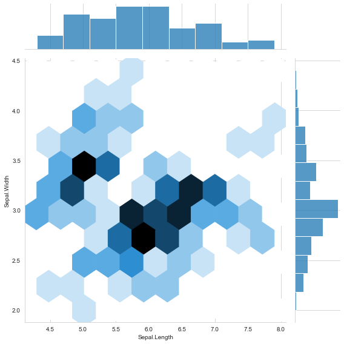

```python
sns.jointplot(data = iris, x='Sepal.Length', y='Sepal.Width', kind='hex', height=8)

plt.show()
```

If we want to modify the marginal distribution settings we can change the keywords.

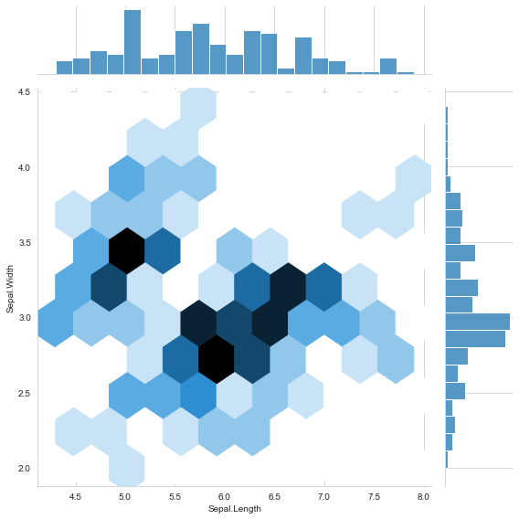

```python
sns.jointplot(data = iris, x='Sepal.Length', y='Sepal.Width', kind='hex', height=8,
              marginal_kws={'bins': 21})

plt.show()
```

We can color by a categorical variable as well.

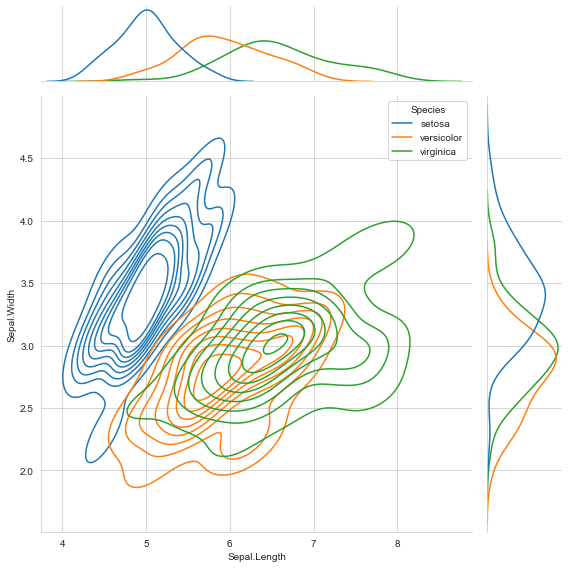

```python
sns.jointplot(data = iris, x='Sepal.Length', y='Sepal.Width', hue='Species', kind='kde', height=8)

plt.show()
```

If we want additional control over the behavior of the plot, we can use the `sns.JointGrid()` function. For example, we can use boxplots for the marginals.

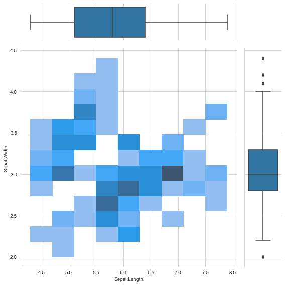

```python
g = sns.JointGrid(data = iris, x='Sepal.Length', y='Sepal.Width', height=8)
g.plot_joint(sns.histplot)
g.plot_marginals(sns.boxplot)

plt.show()
```

We can mix and match representing conditional and ungrouped behavior.

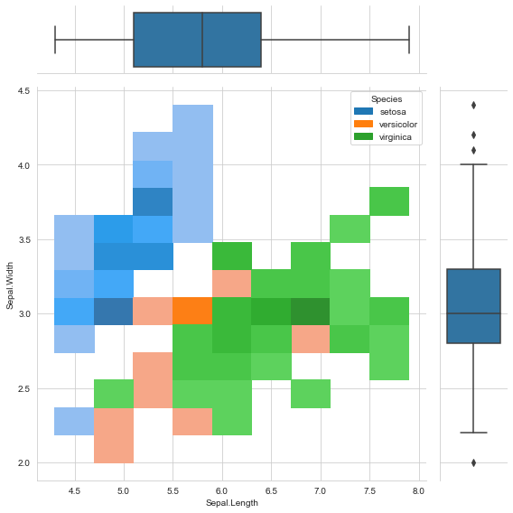

```python
g = sns.JointGrid(data = iris, x='Sepal.Length', y='Sepal.Width', hue='Species', height=8)
g.plot_joint(sns.histplot)
g.plot_marginals(sns.boxplot)

plt.show()
```

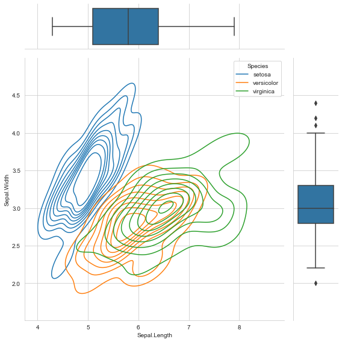

```python
g = sns.JointGrid(data = iris, x='Sepal.Length', y='Sepal.Width', hue='Species', height=8)
g.plot_joint(sns.kdeplot)
g.plot_marginals(sns.boxplot)

plt.show()
```

## Pairsplot

In Seaborn pairsplot only show the continuous variables.

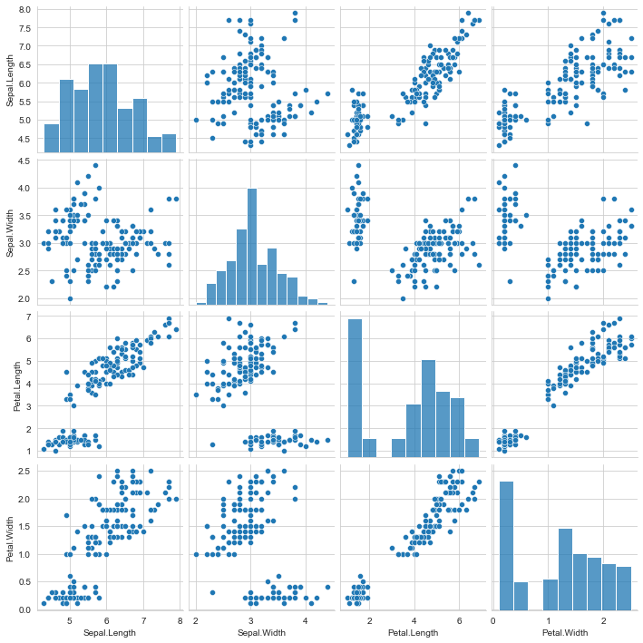

```python
sns.pairplot(iris)

plt.show()
```

We can color the markers and the marginal distributions by categorical variables.

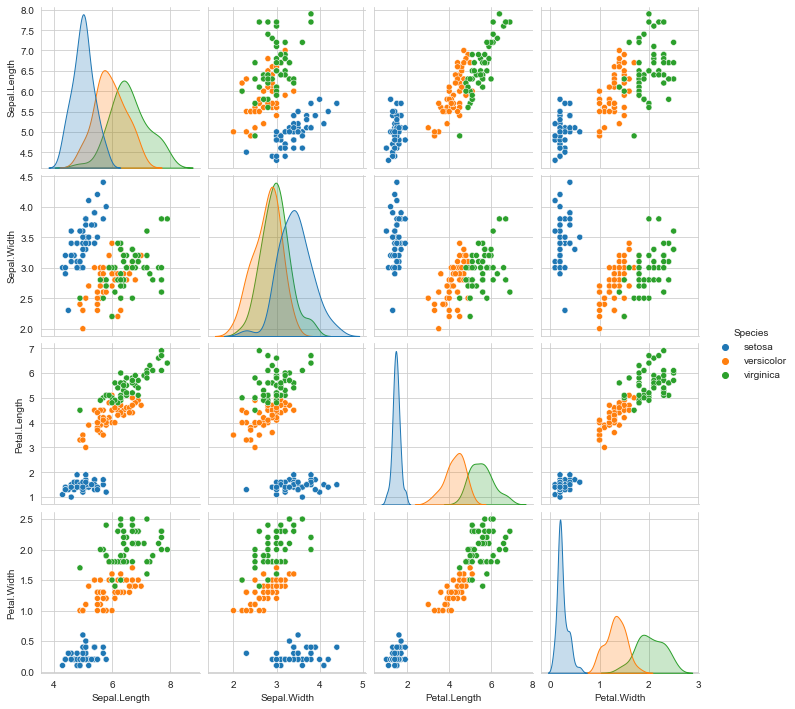

```python
sns.pairplot(data = iris, hue='Species')

plt.show()
```

If we want to control the lower, upper, and diagonal subplots we can use the `sns.PairGrid()` function.

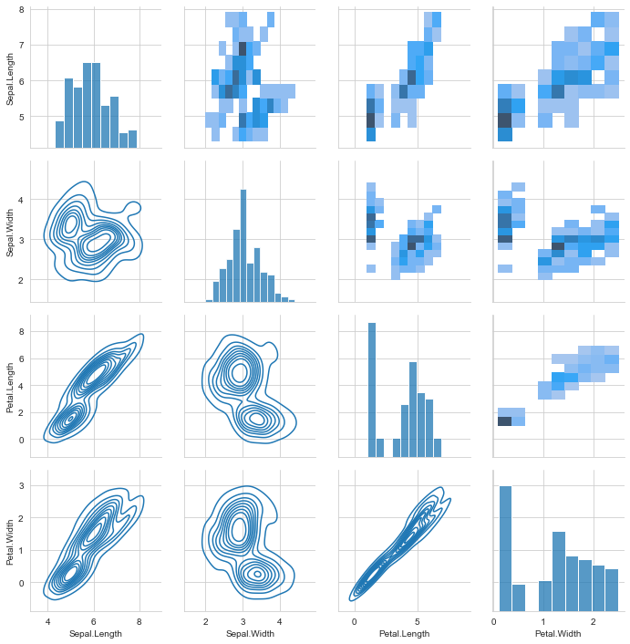

```python
g = sns.PairGrid(iris)

g.map_upper(sns.histplot)
g.map_lower(sns.kdeplot)
g.map_diag(sns.histplot)

plt.show()
```

We can also color by and therefore condition on a categorical variable.

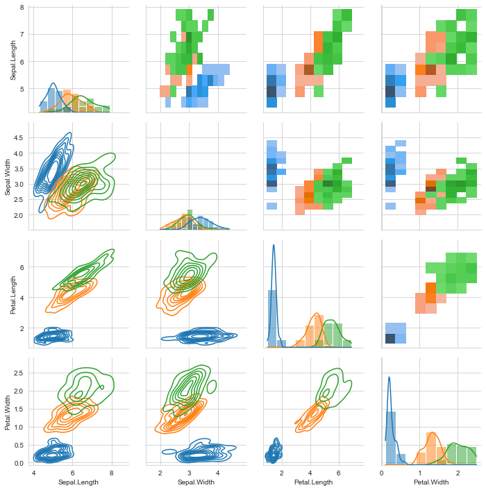

```python
g = sns.PairGrid(iris, hue='Species')

g.map_upper(sns.histplot)
g.map_lower(sns.kdeplot)
g.map_diag(sns.histplot, kde=True)

plt.show()
```